# LinkedIn Job Salary Modeling

Authors

Ian Walsh

Logan Rosell

Published

## 1 Project overview

This report builds a salary classification workflow using LinkedIn job posting data. The goal is to predict whether a posting falls into a lower-, middle-, or upper-salary bin based on text, job metadata, and location fields.

**NoteData sources**

- [LinkedIn Job Postings dataset (Kaggle)](https://www.kaggle.com/datasets/arshkon/linkedin-job-postings)
- [Income bracket reference (Investopedia)](https://www.investopedia.com/upper-middle-and-lower-income-brackets-defined-how-much-income-counts-for-each-category-11932486)

## 2 Setup

```python
import pandas as pd
import numpy as np
import seaborn as sns
import matplotlib.pyplot as plt
import statsmodels.api as sm

from sklearn.model_selection import train_test_split
from sklearn.feature_extraction.text import TfidfVectorizer
from sklearn.preprocessing import OneHotEncoder, LabelEncoder, StandardScaler
from sklearn.decomposition import PCA
from sklearn.linear_model import LinearRegression, LogisticRegression
from sklearn.ensemble import RandomForestClassifier
from sklearn.naive_bayes import GaussianNB
from sklearn.metrics import ConfusionMatrixDisplay, confusion_matrix, cohen_kappa_score, classification_report

import torch
import torch.nn as nn
import torch.optim as optim
```

|  | job_id | company_name | title | description | max_salary | pay_period | location | company_id | views | med_salary | ... | skills_desc | listed_time | posting_domain | sponsored | work_type | currency | compensation_type | normalized_salary | zip_code | fips |
| --- | --- | --- | --- | --- | --- | --- | --- | --- | --- | --- | --- | --- | --- | --- | --- | --- | --- | --- | --- | --- | --- |
| 0 | 921716 | Corcoran Sawyer Smith | Marketing Coordinator | Job descriptionA leading real estate firm in N... | 20.0 | HOURLY | Princeton, NJ | 2774458.0 | 20.0 | NaN | ... | Requirements: \n\nWe are seeking a College or ... | 1.713398e+12 | NaN | 0 | FULL_TIME | USD | BASE_SALARY | 38480.0 | 8540.0 | 34021.0 |
| 1 | 1829192 | NaN | Mental Health Therapist/Counselor | At Aspen Therapy and Wellness , we are committ... | 50.0 | HOURLY | Fort Collins, CO | NaN | 1.0 | NaN | ... | NaN | 1.712858e+12 | NaN | 0 | FULL_TIME | USD | BASE_SALARY | 83200.0 | 80521.0 | 8069.0 |
| 2 | 10998357 | The National Exemplar | Assitant Restaurant Manager | The National Exemplar is accepting application... | 65000.0 | YEARLY | Cincinnati, OH | 64896719.0 | 8.0 | NaN | ... | We are currently accepting resumes for FOH - A... | 1.713278e+12 | NaN | 0 | FULL_TIME | USD | BASE_SALARY | 55000.0 | 45202.0 | 39061.0 |
| 3 | 23221523 | Abrams Fensterman, LLP | Senior Elder Law / Trusts and Estates Associat... | Senior Associate Attorney - Elder Law / Trusts... | 175000.0 | YEARLY | New Hyde Park, NY | 766262.0 | 16.0 | NaN | ... | This position requires a baseline understandin... | 1.712896e+12 | NaN | 0 | FULL_TIME | USD | BASE_SALARY | 157500.0 | 11040.0 | 36059.0 |
| 4 | 35982263 | NaN | Service Technician | Looking for HVAC service tech with experience ... | 80000.0 | YEARLY | Burlington, IA | NaN | 3.0 | NaN | ... | NaN | 1.713452e+12 | NaN | 0 | FULL_TIME | USD | BASE_SALARY | 70000.0 | 52601.0 | 19057.0 |

5 rows × 31 columns

## 3 Data preparation

### 3.1 Cleaning salary values

The `normalized_salary` field contains missing values and a small number of extreme observations. To create a more stable modeling dataset, we first remove postings with missing salary information. We then trim observations below the 3rd percentile and above the 99th percentile of the remaining salary distribution.

Salary categories were defined using 2024 U.S. median household income benchmarks described by [Investopedia](https://www.investopedia.com/upper-middle-and-lower-income-brackets-defined-how-much-income-counts-for-each-category-11932486). The thresholds use two-thirds of the median household income for the lower-income cutoff and twice the median household income for the upper-income cutoff.

| Salary bin | Annual normalized salary |
| --- | --- |
| Lower | $0 to $55,819 |
| Middle | $55,820 to $167,459 |
| Upper | $167,460 and above |

```python
jobs = jobs.copy()

jobs['state'] = jobs['location'].str.split(',', n=1).str[1].str.strip()
jobs['state'] = jobs['state'].where(jobs['state'].str.len() == 2)

jobs_cleaned = jobs.loc[jobs['normalized_salary'].notna()].copy()

lower_bound = jobs_cleaned['normalized_salary'].quantile(0.03)
upper_bound = jobs_cleaned['normalized_salary'].quantile(0.99)

jobs_cleaned = jobs_cleaned.loc[
    jobs_cleaned['normalized_salary'].between(lower_bound, upper_bound)
].copy()

bins = [0, 55820, 167460, float('inf')]
labels = ['lower', 'middle', 'upper']
jobs_cleaned['normalized_salary_bins'] = pd.cut(
    jobs_cleaned['normalized_salary'],
    bins=bins,
    labels=labels,
    include_lowest=True
)
```

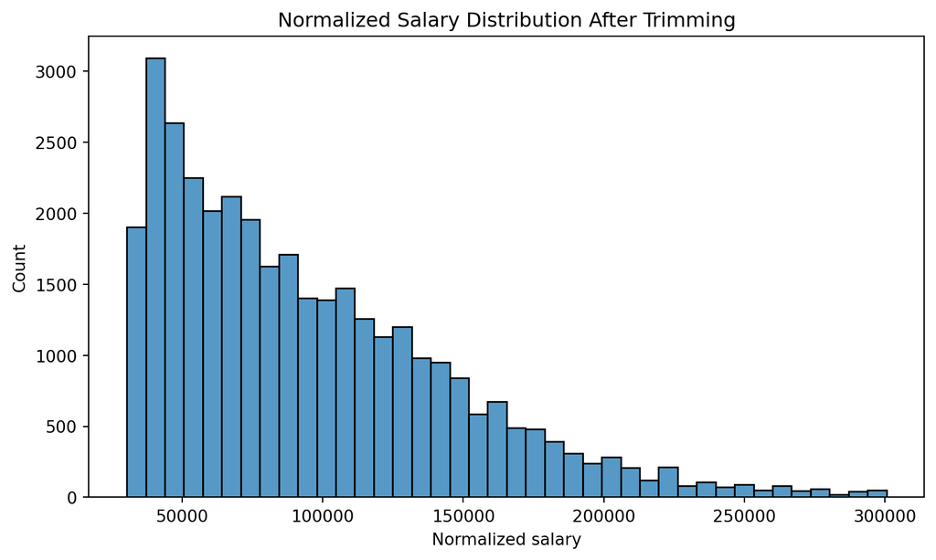

### 3.2 Salary bin balance

```
normalized_salary_bins
lower      9389
middle    21932
upper      3308
Name: count, dtype: int64
```

## 4 Feature engineering

### 4.1 Train-test split

### 4.2 Text features

`skills_desc` is excluded because it is mostly missing.

```python
text_vectorizer = TfidfVectorizer(
    max_df=0.90,
    min_df=0.005,
    max_features=100,
    stop_words='english',
    ngram_range=(1, 2)
)

text_cols = ['company_name', 'title', 'description']
text_train_parts = []
text_test_parts = []

for col in text_cols:
    X_train_raw[col] = X_train_raw[col].fillna('').astype(str)
    X_test_raw[col] = X_test_raw[col].fillna('').astype(str)

    train_mat = text_vectorizer.fit_transform(X_train_raw[col])
    test_mat = text_vectorizer.transform(X_test_raw[col])

    train_df = pd.DataFrame(
        train_mat.toarray(),
        columns=text_vectorizer.get_feature_names_out(),
        index=X_train_raw.index
    ).add_prefix(f'{col}_')

    test_df = pd.DataFrame(
        test_mat.toarray(),
        columns=text_vectorizer.get_feature_names_out(),
        index=X_test_raw.index
    ).add_prefix(f'{col}_')

    text_train_parts.append(train_df)
    text_test_parts.append(test_df)

train_text = pd.concat(text_train_parts, axis=1)
test_text = pd.concat(text_test_parts, axis=1)
```

### 4.3 Categorical features

```python
cat_cols = [
    'pay_period', 'formatted_work_type', 'application_type',
    'formatted_experience_level', 'state'
]

cat_encoder = OneHotEncoder(sparse_output=False, handle_unknown='ignore')

X_train_cat_raw = X_train_raw[cat_cols].fillna('').astype(str)
X_test_cat_raw = X_test_raw[cat_cols].fillna('').astype(str)

train_cat = pd.DataFrame(
    cat_encoder.fit_transform(X_train_cat_raw),
    columns=cat_encoder.get_feature_names_out(cat_cols),
    index=X_train_raw.index
)

test_cat = pd.DataFrame(
    cat_encoder.transform(X_test_cat_raw),
    columns=cat_encoder.get_feature_names_out(cat_cols),
    index=X_test_raw.index
)
```

### 4.4 Numeric features

### 4.5 Combined feature matrix

```
((25971, 324), (8658, 324))
```

### 4.6 PCA summary

PCA is used here as a compact representation of the engineered feature space.

```python
pca = PCA(n_components=5, random_state=0)

X_train_pca = pd.DataFrame(
    pca.fit_transform(X_train_base),
    index=X_train_base.index,
    columns=[f'PCA_{i}' for i in range(1, 6)]
)

X_test_pca = pd.DataFrame(
    pca.transform(X_test_base),
    index=X_test_base.index,
    columns=[f'PCA_{i}' for i in range(1, 6)]
)

pca_variance = pd.DataFrame({
    'component': X_train_pca.columns,
    'explained_variance_ratio': pca.explained_variance_ratio_
})
pca_variance
```

|  | component | explained_variance_ratio |
| --- | --- | --- |
| 0 | PCA_1 | 0.999617 |
| 1 | PCA_2 | 0.000046 |
| 2 | PCA_3 | 0.000038 |
| 3 | PCA_4 | 0.000023 |
| 4 | PCA_5 | 0.000016 |

## 5 Baseline regression screening

A linear regression on the continuous salary target provides a rough screening step for potentially useful engineered predictors.

```python
regression = LinearRegression()
regression.fit(X_train_base, y_train['normalized_salary'])

X2 = sm.add_constant(X_train_base)
est2 = sm.OLS(y_train['normalized_salary'], X2).fit()

p_values = est2.pvalues
significant_vars = p_values[p_values < 0.05].index.drop('const').tolist()
len(significant_vars)
print(est2.summary())
```

```
                            OLS Regression Results
==============================================================================
Dep. Variable:      normalized_salary   R-squared:                       0.566
Model:                            OLS   Adj. R-squared:                  0.561
Method:                 Least Squares   F-statistic:                     105.0
Date:                Wed, 19 Aug 2026   Prob (F-statistic):               0.00
Time:                        09:36:31   Log-Likelihood:            -3.0733e+05
No. Observations:               25971   AIC:                         6.153e+05
Df Residuals:                   25651   BIC:                         6.179e+05
Df Model:                         319
Covariance Type:            nonrobust
===============================================================================================================
                                                  coef    std err          t      P>|t|      [0.025      0.975]
---------------------------------------------------------------------------------------------------------------
const                                         4.79e+04   5725.153      8.366      0.000    3.67e+04    5.91e+04
views                                           0.1338      1.858      0.072      0.943      -3.508       3.775
company_name_amazon                          7263.0250   3329.136      2.182      0.029     737.730    1.38e+04
company_name_america                        -4008.7994   2649.010     -1.513      0.130   -9201.009    1183.410
company_name_bank                           -4522.6759   2339.650     -1.933      0.053   -9108.521      63.170
company_name_california                      2127.4446   3630.200      0.586      0.558   -4987.953    9242.842
company_name_care                           -5786.1683   2586.214     -2.237      0.025   -1.09e+04    -717.044
company_name_center                         -1.133e+04   2778.705     -4.077      0.000   -1.68e+04   -5883.071
company_name_city                            -667.0702   3109.750     -0.215      0.830   -6762.356    5428.216
company_name_companies                      -5391.8641   2827.558     -1.907      0.057   -1.09e+04     150.310
company_name_company                         -138.1395   1830.398     -0.075      0.940   -3725.822    3449.543
company_name_consulting                     -2483.3308   2266.858     -1.095      0.273   -6926.501    1959.840
company_name_corporation                    -3004.1203   2170.863     -1.384      0.166   -7259.135    1250.894
company_name_county                         -1899.8435   3116.529     -0.610      0.542   -8008.417    4208.730
company_name_creative                       -1.228e+04   4380.131     -2.804      0.005   -2.09e+04   -3694.598
company_name_department                     -1.077e+04   3216.512     -3.348      0.001   -1.71e+04   -4465.536
company_name_financial                      -7362.4270   3386.952     -2.174      0.030    -1.4e+04    -723.809
company_name_global                          2283.6066   3347.015      0.682      0.495   -4276.732    8843.945
company_name_group                           -233.2253   1137.035     -0.205      0.837   -2461.879    1995.428
company_name_health                         -1102.6401   1455.175     -0.758      0.449   -3954.865    1749.585
company_name_healthcare                      -749.5392   2023.101     -0.370      0.711   -4714.932    3215.854
company_name_insight                        -3.091e+04   1.32e+04     -2.338      0.019   -5.68e+04   -5000.906
company_name_insight global                  2.661e+04    1.4e+04      1.895      0.058    -912.961    5.41e+04
company_name_insurance                      -8242.6231   3341.940     -2.466      0.014   -1.48e+04   -1692.231
company_name_international                   -391.7631   2047.483     -0.191      0.848   -4404.945    3621.419
company_name_job                             2.804e+04   8869.169      3.162      0.002    1.07e+04    4.54e+04
```

[output cut: 295 more lines]

```
state_WA                                     1.235e+04   1167.705     10.580      0.000    1.01e+04    1.46e+04
state_WI                                     -983.7941   1860.983     -0.529      0.597   -4631.426    2663.838
state_WV                                    -1811.0264   6923.340     -0.262      0.794   -1.54e+04    1.18e+04
state_WY                                     2304.5832   7613.306      0.303      0.762   -1.26e+04    1.72e+04
==============================================================================
Omnibus:                     6398.075   Durbin-Watson:                   1.998
Prob(Omnibus):                  0.000   Jarque-Bera (JB):            21347.407
Skew:                           1.237   Prob(JB):                         0.00
Kurtosis:                       6.688   Cond. No.                     8.50e+17
==============================================================================

Notes:
[1] Standard Errors assume that the covariance matrix of the errors is correctly specified.
[2] The smallest eigenvalue is 4.83e-28. This might indicate that there are
strong multicollinearity problems or that the design matrix is singular.
```

```python
X_train_sig = pd.concat([X_train_base[significant_vars], X_train_pca], axis=1)
X_test_sig = pd.concat([X_test_base[significant_vars], X_test_pca], axis=1)

X_train_sig.shape, X_test_sig.shape
```

```
((25971, 191), (8658, 191))
```

## 6 Modeling

### 6.1 Random forest

```
0.6404924863052626
```

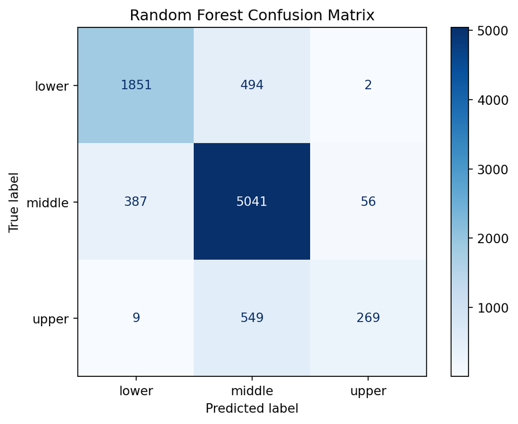

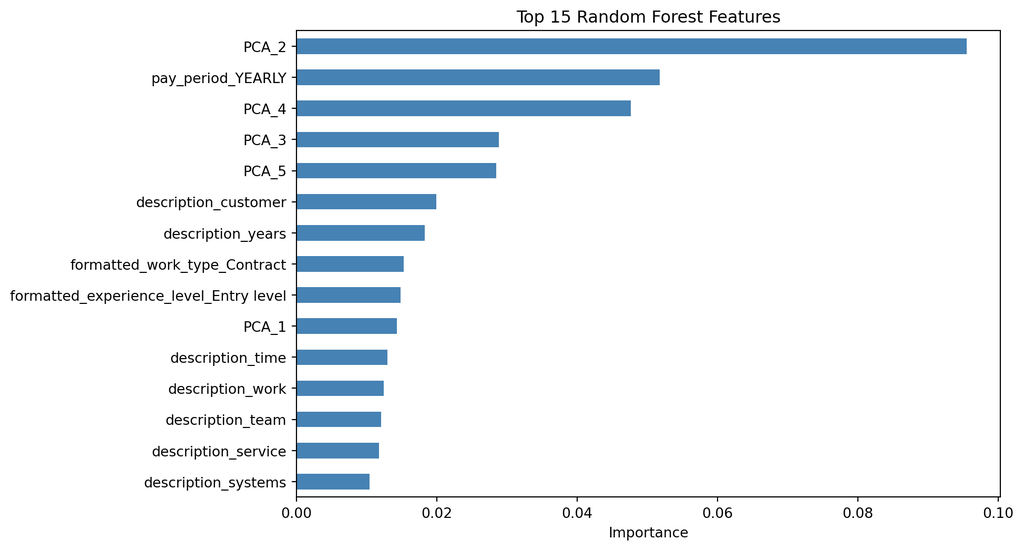

### 6.2 Logistic regression

```
0.5710016378480647
```

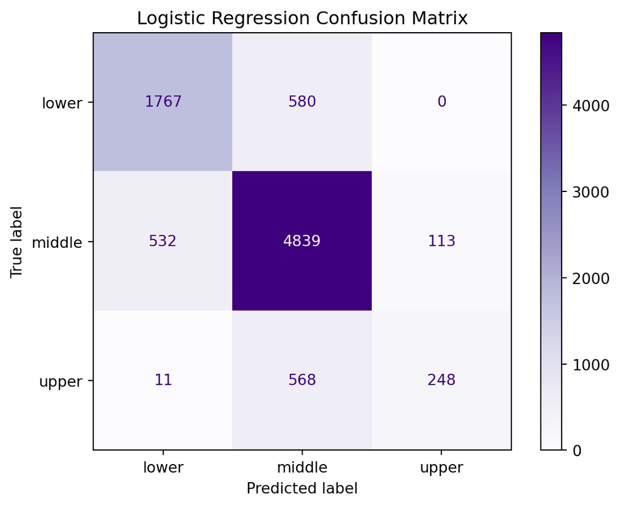

### 6.3 Naive Bayes

```
0.2622450912193507
```

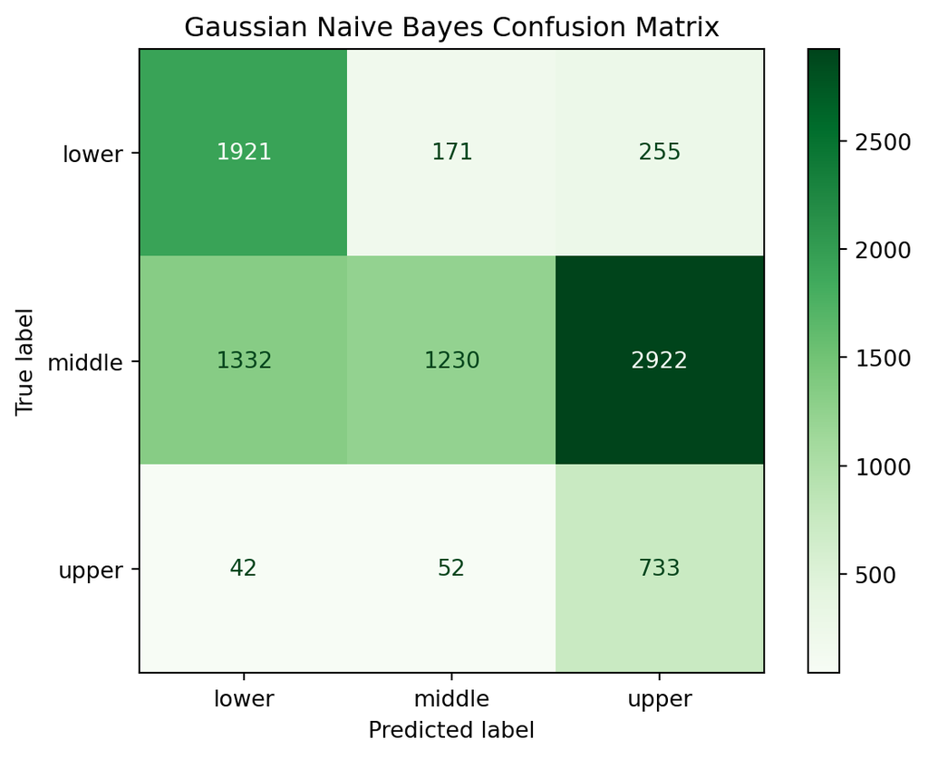

### 6.4 Neural network

```
0.5249493113980875
```

## 7 Model results

|  | model | cohen_kappa_test |
| --- | --- | --- |
| 0 | Random Forest | 0.640492 |
| 1 | Logistic Regression | 0.571002 |
| 3 | Neural Network | 0.524949 |
| 2 | Gaussian Naive Bayes | 0.262245 |

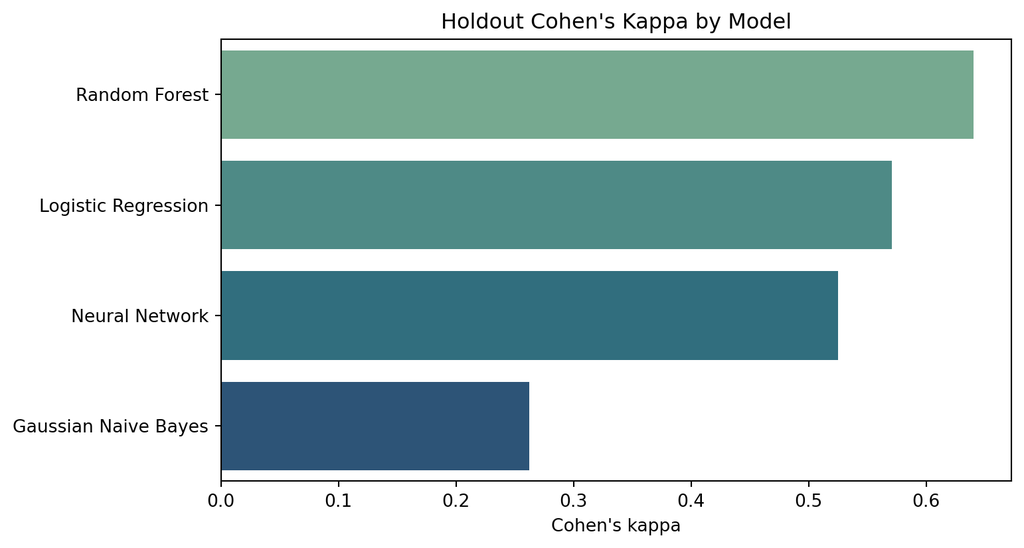

## 8 Notes and limitations

**ImportantModeling caveats**

- Salary thresholds are externally defined and may not map cleanly to job-market segments in the source data.
- The workflow relies heavily on text fields, which can be noisy and unstable across employers.
- Feature screening via linear regression is useful for compactness, but it is not a substitute for pipeline-based cross-validation.
- PCA improves compactness but reduces interpretability and changes which models are appropriate.